# Import necessary packages

```python
# Load the necessary packages

import numpy as np
import pandas as pd
import matplotlib.pyplot as plt
import seaborn as sns
import math
import scipy.stats as stats
from scipy.stats import binom
from scipy.stats import poisson
from scipy.stats import ttest_ind
from scipy.stats import chi2_contingency
from google.colab import drive
from datetime import datetime

drive.mount('/content/drive')
%matplotlib inline
```

# PART A

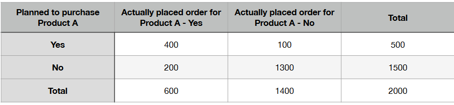

**1.A.** Refer above table and find the joint probability of the people who planned to purchase and actually placed an order.

```python
a_placed = 400
total = 2000
prob = a_placed/total
prob
```

```
0.2
```

**1.B.** Refer to the above table and find the joint probability of the people who planned to purchase and actually placed an order, given that people planned to purchase.

```python
a_placed = 400
planned_to_purchase = 500
prob = a_placed/planned_to_purchase
prob
```

```
0.8
```

**2.** An electrical manufacturing company conducts quality checks at specified periods on the products it manufactures. Historically, the failure rate for the manufactured item is 5%. Suppose a random sample of 10 manufactured items is selected. Answer the following questions. [4 Marks]

**2.A.** Probability that none of the items are defective? [1 Mark] **2.B.** Probability that exactly one of the items is defective? [1 Mark] **2.C.** Probability that two or fewer of the items are defective? [1 Mark] **2.D.** Probability that three or more of the items are defective ? [1 Mark]

```python
n = 10
p = 0.05
k = np.arange(0,n+1)

pmf = binom.pmf(k,n,p)

print("2.A. -Probability that none of the items are defective:", pmf[0])
```

```
2.A. -Probability that none of the items are defective: 0.5987369392383787
```

```python
print("2.B. -Probability that exactly one of the items is defective:", pmf[1])
```

```
2.B. -Probability that exactly one of the items is defective: 0.3151247048623047
```

```python
cdf = binom.cdf(k,n,p)
print("2.C. -Probability that that two or fewer of the items are defective:", cdf[2])
```

```
2.C. -Probability that that two or fewer of the items are defective: 0.9884964426207031
```

```python
print("2.D. -Probability that three or more of the items are defective:", 1-cdf[2])
```

```
2.D. -Probability that three or more of the items are defective: 0.01150355737929687
```

**3.** A car salesman sells on an average 3 cars per week. [3 Marks]

**3.A.** What is Probability that in a given week he will sell some cars? [1 Mark] **3.B.** What is Probability that in a given week he will sell 2 or more but less than 5 cars? [1 Mark] **3.C.** Plot the poisson distribution function for cumulative probability of cars sold per-week vs number of cars sold per week. [1 Mark]

```python
mean = 3

# probability that in a given week he will sell some cars
s_cars = 1 - poisson.cdf(0, mean)
print("3A - Probability of selling some cars:", s_cars)
```

```
3A - Probability of selling some cars: 0.950212931632136
```

```python
t_m_cars = poisson.cdf(1, mean)
f_cars = poisson.cdf(4, mean)

prob = f_cars - t_m_cars
print("Probability of selling 2 or more and less than 5 cars:", prob )
```

```
Probability of selling 2 or more and less than 5 cars: 0.6161149710523164
```

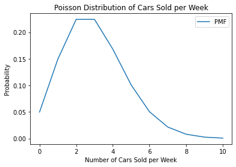

```python
x = np.arange(0, 11)
y = poisson.pmf(x, mean)

sns.lineplot(x, y, label='PMF');
plt.title('Poisson Distribution of Cars Sold per Week')
plt.xlabel('Number of Cars Sold per Week')
plt.ylabel('Probability')
plt.show();
```

1. Accuracy in understanding orders for a speech based bot at a restaurant is important for the Company X which has designed, marketed and launched the product for a contactless delivery due to the COVID-19 pandemic. Recognition accuracy that measures the percentage of orders that are taken correctly is 86.8%. Suppose that you place an order with the bot and two friends of yours independently place orders with the same bot. Answer the following questions.

4.A. What is the probability that all three orders will be recognised correctly?

4.B. What is the probability that none of the three orders will be recognised correctly?

4.C. What is the probability that at least two of the three orders will be recognised correctly?

```python
n = 3
p = 0.868

dist = binom(n, p)

# Probability of all three orders correct
p_all_3_c = dist.pmf(n)

print("4.A. probability of all three orders recognized correctly =", p_all_3_c)
```

```
4.A. probability of all three orders recognized correctly = 0.653972032
```

```python
# Probability of none of the three orders correct
p_n_c = dist.pmf(0)

print("4.B The probability of none of the orders recognized correct =" ,p_n_c)
```

```
4.B The probability of none of the orders recognized correct = 0.0022999680000000003
```

```python
# Probability of at least two of the three orders correct
prob = 1 - dist.cdf(1)

print("4.C. The probability of at least two of the three orders recognized correct = ", prob)
```

```
4.C. The probability of at least two of the three orders recognized correct =  0.952327936
```

1. Explain 1 real life industry scenario (other than the ones mentioned above) where you can use the concepts learnt in this module of Applied Statistics to get data driven business solution.

Hypothesis testing is a statistical technique that can be used to test a hypothesis about a population based on a sample of data. One real-life example where hypothesis testing can be used to get data-driven business solutions is in procurement in terms of hold or not hold any new purchase requisition.

Suppose a company has last 15 years of purchase requisition details and consumption details and want to know probability of material purchase needs with new purchase requisition of likely hood of utilization.

To do this, the company could collect a last 5 years of material purchase and consumption information of material and from data we can perform a hypothesis test to determine whether there is a significant chance of material getting consumed or not and based on this probability business can take call for not ordering the material immediately instead of that we can hold for some time to purchase this material.

The null hypothesis for this test would be that material in purchase requisition going to consumed, while the alternative hypothesis would be that material in purchase requisition not going to consumed.

If the hypothesis test results in a rejection of the null hypothesis then material in purchase requisition need to hold.

Overall, hypothesis testing provides a powerful tool for businesses to make data-driven decisions and determine the likely hood of consumptions.

# PART B

**CONTEXT:** Company X manages the men's top professional basketball division of the American league system. The dataset contains information on all the teams that have participated in all the past tournaments. It has data about how many baskets each team scored, conceded, how many times they came within the first 2 positions, how many tournaments they have qualified, their best position in the past, etc.

```python
# Read the data set, clean the data and prepare final dataset to be used for analysis.
Data = pd.read_csv('/content/drive/My Drive/AIML/Applied Statistic/Project/Basketball.csv')
```

```python
Data.head()
```

|  | Team | Tournament | Score | PlayedGames | WonGames | DrawnGames | LostGames | BasketScored | BasketGiven | TournamentChampion | Runner-up | TeamLaunch | HighestPositionHeld |
| --- | --- | --- | --- | --- | --- | --- | --- | --- | --- | --- | --- | --- | --- |
| 0 | Team 1 | 86 | 4385 | 2762 | 1647 | 552 | 563 | 5947 | 3140 | 33 | 23 | 1929 | 1 |
| 1 | Team 2 | 86 | 4262 | 2762 | 1581 | 573 | 608 | 5900 | 3114 | 25 | 25 | 1929 | 1 |
| 2 | Team 3 | 80 | 3442 | 2614 | 1241 | 598 | 775 | 4534 | 3309 | 10 | 8 | 1929 | 1 |
| 3 | Team 4 | 82 | 3386 | 2664 | 1187 | 616 | 861 | 4398 | 3469 | 6 | 6 | 1931to32 | 1 |
| 4 | Team 5 | 86 | 3368 | 2762 | 1209 | 633 | 920 | 4631 | 3700 | 8 | 7 | 1929 | 1 |

```python
Data.tail()
```

|  | Team | Tournament | Score | PlayedGames | WonGames | DrawnGames | LostGames | BasketScored | BasketGiven | TournamentChampion | Runner-up | TeamLaunch | HighestPositionHeld |
| --- | --- | --- | --- | --- | --- | --- | --- | --- | --- | --- | --- | --- | --- |
| 56 | Team 57 | 1 | 34 | 38 | 8 | 10 | 20 | 38 | 66 | - | - | 2009-10 | 20 |
| 57 | Team 58 | 1 | 22 | 30 | 7 | 8 | 15 | 37 | 57 | - | - | 1956-57 | 16 |
| 58 | Team 59 | 1 | 19 | 30 | 7 | 5 | 18 | 51 | 85 | - | - | 1951~52 | 16 |
| 59 | Team 60 | 1 | 14 | 30 | 5 | 4 | 21 | 34 | 65 | - | - | 1955-56 | 15 |
| 60 | Team 61 | 1 | - | - | - | - | - | - | - | - | - | 2017~18 | 9 |

```python
Data.info()
```

```
<class 'pandas.core.frame.DataFrame'>
RangeIndex: 61 entries, 0 to 60
Data columns (total 13 columns):
 #   Column               Non-Null Count  Dtype
---  ------               --------------  -----
 0   Team                 61 non-null     object
 1   Tournament           61 non-null     int64
 2   Score                61 non-null     object
 3   PlayedGames          61 non-null     object
 4   WonGames             61 non-null     object
 5   DrawnGames           61 non-null     object
 6   LostGames            61 non-null     object
 7   BasketScored         61 non-null     object
 8   BasketGiven          61 non-null     object
 9   TournamentChampion   61 non-null     object
 10  Runner-up            61 non-null     object
 11  TeamLaunch           61 non-null     object
 12  HighestPositionHeld  61 non-null     int64
dtypes: int64(2), object(11)
memory usage: 6.3+ KB
```

```python
# lets replace - with 0 so that column converted to int
Data['TournamentChampion'] = Data['TournamentChampion'].replace('-', 0)
Data['Runner-up'] = Data['Runner-up'].replace('-', 0)
Data['PlayedGames'] = Data['PlayedGames'].replace('-', 0)

# dropping team not played single games.
Data['PlayedGames'] = Data['PlayedGames'].astype(int)
Data = Data.drop(Data[Data['PlayedGames'] < 1].index)

Data['Score'] = Data['Score'].astype(int)
Data['WonGames'] = Data['WonGames'].astype(int)
Data['DrawnGames'] = Data['DrawnGames'].astype(int)
Data['LostGames'] = Data['LostGames'].astype(int)
Data['BasketScored'] = Data['BasketScored'].astype(int)
Data['BasketGiven'] = Data['BasketGiven'].astype(int)
Data['TournamentChampion'] = Data['TournamentChampion'].astype(int)
Data['Runner-up'] = Data['Runner-up'].astype(int)
Data['HighestPositionHeld'] = Data['HighestPositionHeld'].astype(int)

# consider only YYYY for Team Launch
Data['TeamLaunch'] = Data['TeamLaunch'].str[:4]
```

```python
# Calculate summary statistics, such as mean, median, standard deviation, minimum, and maximum, for each variable.
Data.describe()
```

|  | Tournament | Score | PlayedGames | WonGames | DrawnGames | LostGames | BasketScored | BasketGiven | TournamentChampion | Runner-up | HighestPositionHeld |
| --- | --- | --- | --- | --- | --- | --- | --- | --- | --- | --- | --- |
| count | 60.000000 | 60.000000 | 60.000000 | 60.000000 | 60.000000 | 60.000000 | 60.000000 | 60.000000 | 60.00000 | 60.000000 | 60.000000 |
| mean | 24.383333 | 916.450000 | 810.100000 | 309.033333 | 192.083333 | 308.816667 | 1159.350000 | 1159.233333 | 1.45000 | 1.433333 | 7.050000 |
| std | 26.884620 | 1138.342899 | 877.465393 | 408.481395 | 201.985508 | 294.508639 | 1512.063948 | 1163.946914 | 5.51554 | 4.574679 | 5.315232 |
| min | 1.000000 | 14.000000 | 30.000000 | 5.000000 | 4.000000 | 15.000000 | 34.000000 | 55.000000 | 0.00000 | 0.000000 | 1.000000 |
| 25% | 4.000000 | 104.250000 | 115.500000 | 34.750000 | 26.250000 | 62.750000 | 154.500000 | 236.000000 | 0.00000 | 0.000000 | 3.000000 |
| 50% | 12.000000 | 395.500000 | 424.500000 | 124.000000 | 98.500000 | 197.500000 | 444.000000 | 632.500000 | 0.00000 | 0.000000 | 6.000000 |
| 75% | 39.000000 | 1360.500000 | 1345.500000 | 432.750000 | 331.500000 | 563.500000 | 1669.750000 | 2001.250000 | 0.00000 | 0.000000 | 10.000000 |
| max | 86.000000 | 4385.000000 | 2762.000000 | 1647.000000 | 633.000000 | 1070.000000 | 5947.000000 | 3889.000000 | 33.00000 | 25.000000 | 20.000000 |

```python
# Create a new feature how old Team is
Data['YearsAgo-TeamLaunch'] = datetime.now().year - pd.to_numeric(Data['TeamLaunch'])

# Create a new feature % of Won, avg of basket given, avg of basket scored and scored
Data = Data.assign(wonper = Data['WonGames'] / Data['PlayedGames'] * 100)
Data = Data.assign(avgBasketgiven =  Data['BasketGiven'] / Data['PlayedGames'])
Data = Data.assign(avgBasketscored =  Data['BasketScored'] / Data['PlayedGames'])
Data = Data.assign(avgscored =  Data['Score'] / Data['PlayedGames'])
```

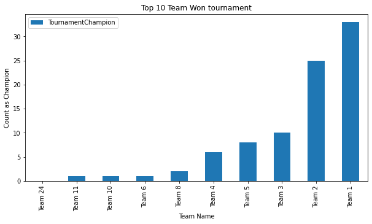

```python
df = Data.sort_values(['TournamentChampion']).tail(10)
df.plot(x='Team',y='TournamentChampion',kind='bar',figsize=(10,5))
plt.title('Top 10 Team Won tournament')
plt.xlabel('Team Name')
plt.ylabel('Count as Champion')
plt.show()
```

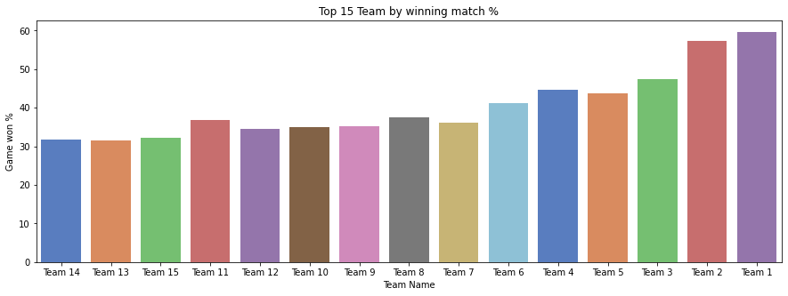

```python
plt.figure(figsize=(15,5))  # setting the figure size
plt.title('Top 15 Team by winning match %')
df = Data.sort_values(['WonGames']).tail(15)
ax = sns.barplot(x='Team', y='wonper', data=df, palette='muted');  # barplot
ax.set_xlabel("Team Name");
ax.set_ylabel("Game won %");
```

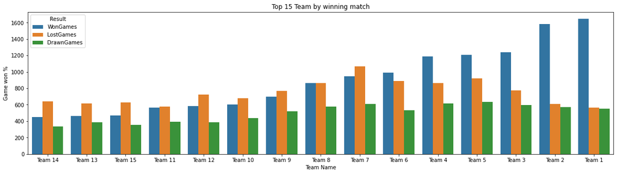

```python
df = Data.loc[:, ['Team', 'WonGames','LostGames','DrawnGames']]
df = df.sort_values(['WonGames']).tail(15)
# Melt the DataFrame to convert the data from wide to long format
melted_df = df.melt(id_vars='Team', var_name='Result', value_name='Count')

plt.figure(figsize=(20,5))
plt.title('Top 15 Team by winning match')

ax = sns.barplot(x='Team', y='Count', hue='Result', data=melted_df)
ax.set_xlabel("Team Name");
ax.set_ylabel("Game won %");

plt.show()
```

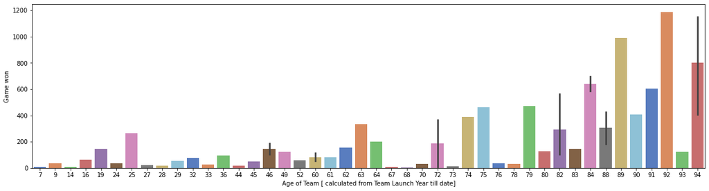

```python
plt.figure(figsize=(20,5))  # setting the figure size
ax = sns.barplot(x='YearsAgo-TeamLaunch', y='WonGames', data=Data, palette='muted')
ax.set_xlabel("Age of Team [ calculated from Team Launch Year till date]");
ax.set_ylabel("Game won");
```

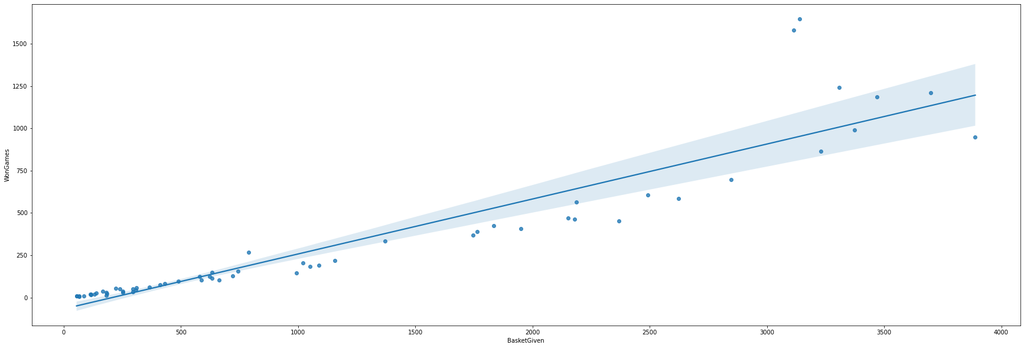

```python
figure = plt.figure(figsize=(30,10))

ax = sns.regplot(x='BasketGiven',y='WonGames', data=Data )
```

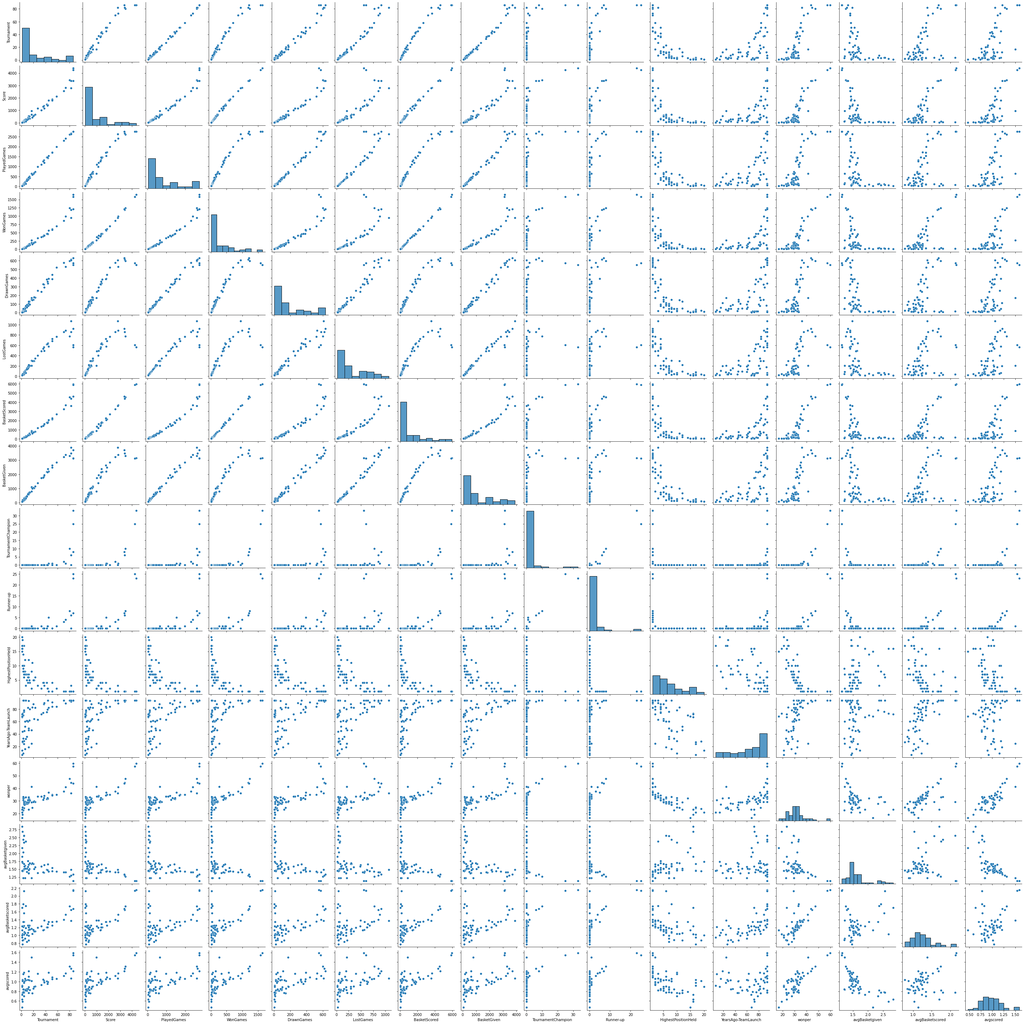

```python
sns.pairplot(Data);
```

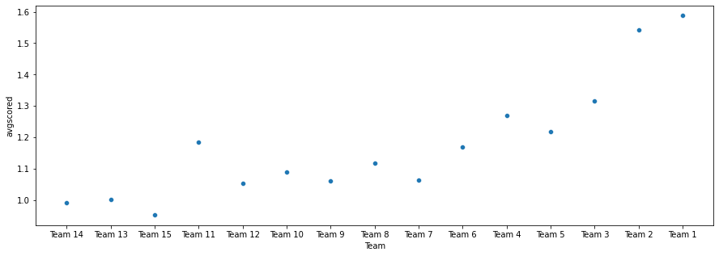

```python
df = Data.sort_values(['WonGames']).tail(15)

fig, ax = plt.subplots(figsize=(15, 5))
sns.scatterplot(x='Team', y='avgscored', data=df, ax=ax);
```

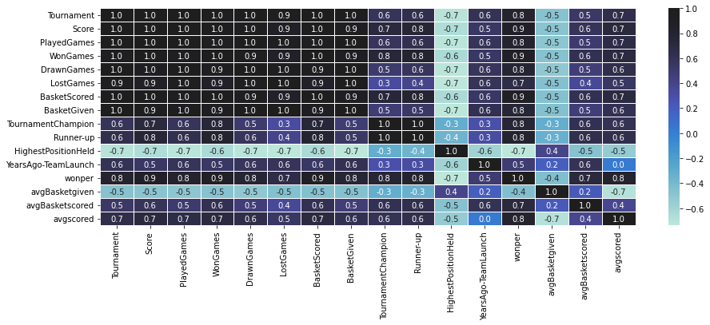

```python
plt.figure(figsize=(15,5))
sns.heatmap(Data.corr(), annot=True, linewidths=.5, fmt= '.1f', center = 1 )  # heatmap
plt.show();
```

Please include any improvements or suggestions to the association management on quality, quantity, variety, velocity, veracity etc. on the data points collected by the association to perform a better data analysis in future. At-least 1 suggestion for each point.

Quality:

1. Use standardized data formats to reduce errors and inconsistencies in data
2. Implement data validation checks to ensure that data is accurate, consistent, and complete. like team palyed tournament but played match is "-" is incorrect.

Quantity:

1. Collect data at more frequent intervals to increase the amount of data collected, like Data by Tournament years and matches palyed against whcih team.

Variety:

1. Collect different types of data to provide a more comprehensive view of the team to analyzed, like fouls commited, Fouls Won, Top Scorer by tournament or by year, Team Manager, Match score Card to identify winning is comprehensive or difficult and same for lost matches.

Velocity:

1. it seems data is not collected as Automate processes due to very less information available this should be automate to reduce the time and effort required to collect data.
2. per match details should be capture so that more variety of data is aviabale near real time for analysis also.

Veracity:

1. Implement data policies and procedures to ensure that data is accurate and consistent. like Team lunch year should be in single format, palyed, won, loss, draw etc should be numeric not object.

# PART C

**CONTEXT:** Company X is a EU online publisher focusing on the startups industry. The company specifically reports on the business related to technology news, analysis of emerging trends and profiling of new tech businesses and products. Their event i.e. Startup Battlefield is the world’s pre-eminent startup competition. Startup Battlefield features 15-30 top early stage startups pitching top judges in front of a vast live audience, present in person and online.

```python
# Read the csv file,
Data = pd.read_csv('/content/drive/My Drive/AIML/Applied Statistic/Project/CompanyX_EU.csv')
# show top 5 data points
Data.head()
```

|  | Startup | Product | Funding | Event | Result | OperatingState |
| --- | --- | --- | --- | --- | --- | --- |
| 0 | 2600Hz | 2600hz.com | NaN | Disrupt SF 2013 | Contestant | Operating |
| 1 | 3DLT | 3dlt.com | $630K | Disrupt NYC 2013 | Contestant | Closed |
| 2 | 3DPrinterOS | 3dprinteros.com | NaN | Disrupt SF 2016 | Contestant | Operating |
| 3 | 3Dprintler | 3dprintler.com | $1M | Disrupt NY 2016 | Audience choice | Operating |
| 4 | 42 Technologies | 42technologies.com | NaN | Disrupt NYC 2013 | Contestant | Operating |

```python
# check the datatypes of each attributes
Data.info()
```

```
<class 'pandas.core.frame.DataFrame'>
RangeIndex: 662 entries, 0 to 661
Data columns (total 6 columns):
 #   Column          Non-Null Count  Dtype
---  ------          --------------  -----
 0   Startup         662 non-null    object
 1   Product         656 non-null    object
 2   Funding         448 non-null    object
 3   Event           662 non-null    object
 4   Result          662 non-null    object
 5   OperatingState  662 non-null    object
dtypes: object(6)
memory usage: 31.2+ KB
```

```python
# Check for null values in the attributes.
pd.DataFrame( Data.isnull().sum(), columns= ['Number of missing values'])
```

|  | Number of missing values |
| --- | --- |
| Startup | 0 |
| Product | 6 |
| Funding | 214 |
| Event | 0 |
| Result | 0 |
| OperatingState | 0 |

```python
# Drop the null values.
Data.dropna(inplace=True)  # Drops all the rows that have atleast one missing values
pd.DataFrame( Data.isnull().sum(), columns= ['Number of missing values'])
```

|  | Number of missing values |
| --- | --- |
| Startup | 0 |
| Product | 0 |
| Funding | 0 |
| Event | 0 |
| Result | 0 |
| OperatingState | 0 |

```python
# Convert the 'Funding' features to a numerical value
Data.loc[:,'Funds_in_million'] = Data['Funding'].apply(lambda x: float(x[1:-1])/1000 if x[-1] == 'K' else (float(x[1:-1])*1000 if x[-1] == 'B' else float(x[1:-1])))
```

```python
Data.info()
```

```
<class 'pandas.core.frame.DataFrame'>
Int64Index: 446 entries, 1 to 661
Data columns (total 7 columns):
 #   Column            Non-Null Count  Dtype
---  ------            --------------  -----
 0   Startup           446 non-null    object
 1   Product           446 non-null    object
 2   Funding           446 non-null    object
 3   Event             446 non-null    object
 4   Result            446 non-null    object
 5   OperatingState    446 non-null    object
 6   Funds_in_million  446 non-null    float64
dtypes: float64(1), object(6)
memory usage: 27.9+ KB
```

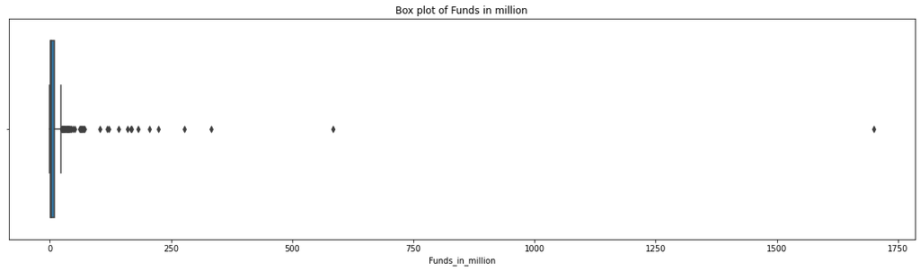

```python
#Plot box plot for funds in million.
plt.figure(figsize=(20,5))
plt.title('Box plot of Funds in million')
ax = sns.boxplot(x=Data['Funds_in_million'])   # box plot
```

```python
# Check the number of outliers greater than the upper fence.

Q3 = Data['Funds_in_million'].quantile(0.75)
Q1 = Data['Funds_in_million'].quantile(0.25)
IQR = Q3 - Q1
upper_fence = Q3 + 1.5 * IQR

# number of outliers greater than the upper fence
num_outliers = len(Data[Data['Funds_in_million'] > upper_fence])

print("Number of outliers greater than upper fence:", num_outliers)
```

```
Number of outliers greater than upper fence: 60
```

```python
# Check frequency of the OperatingState features classes.
Data['OperatingState'].value_counts()
```

```
Operating    319
Acquired      66
Closed        57
Ipo            4
Name: OperatingState, dtype: int64
```

**Statistical Analysis:**

1. Is there any significant difference between Funds raised by companies that are still operating vs companies that closed down?

```python
from scipy.stats import ttest_ind

# assume significance level
alpha = 0.05
operating_funds = Data[Data['OperatingState'] == 'Operating']['Funds_in_million']
closed_funds = Data[Data['OperatingState'] == 'Closed']['Funds_in_million']

t_statistic, p_value = ttest_ind(operating_funds, closed_funds, equal_var=False)

print('P-Value:', p_value)

if p_value < alpha:
  print("we reject the null hypothesis and conclude that there is a significant difference between the funds raised by startups operating and closed.")
else:
  print("we accpet the null hypothesis and conclude that there is no significant difference in the funds raised by  startups that are operating versus closed.")
```

```
P-Value: 0.007898898722704632
we reject the null hypothesis and conclude that there is a significant difference between the funds raised by startups operating and closed.
```

# *Write the null hypothesis and alternative hypothesis*.

The **null hypothesis** is that there is no significant difference in the funds raised by companies that are still operating versus companies that have closed down.

The **alternative hypothesis** is that there is a significant difference in the funds raised by companies that are still operating versus companies that have closed down.

```python
# Test for significance and conclusion
alpha = 0.05
operating_funds = Data[Data['OperatingState'] == 'Operating']['Funds_in_million']
closed_funds = Data[Data['OperatingState'] == 'Closed']['Funds_in_million']

t_statistic, p_value = ttest_ind(operating_funds, closed_funds, equal_var=False)

print('P-Value:', p_value)

if p_value < alpha:
  print("we reject the null hypothesis and conclude that there is a significant difference between the funds raised by startups operating and closed.")
else:
  print("we accpet the null hypothesis and conclude that there is no significant difference in the funds raised by  startups that are operating versus closed.")
```

```
P-Value: 0.007898898722704632
we reject the null hypothesis and conclude that there is a significant difference between the funds raised by startups operating and closed.
```

```python
# Make a copy of the original data frame.
# Read the csv file,
df = pd.read_csv('/content/drive/My Drive/AIML/Applied Statistic/Project/CompanyX_EU.csv')
dfCopy = df.copy(deep=True);
dfCopy.head()

DataCopy = Data.copy(deep=True);
```

```python
# Check frequency distribution of Result variables.
dfCopy['Result'].value_counts()
```

```
Contestant         488
Finalist            84
Audience choice     41
Winner              26
Runner up           23
Name: Result, dtype: int64
```

```python
# Check frequency distribution of Result variables.
DataCopy['Result'].value_counts()
```

```
Contestant         312
Finalist            65
Audience choice     25
Winner              25
Runner up           19
Name: Result, dtype: int64
```

```python
# Calculate percentage of winners that are still operating and percentage of contestants that are still operating

df_filtered = dfCopy[dfCopy['Result'].isin(['Winner', 'Contestant'])]

# calculate percentage of winners that are still operating
winners_operating = df_filtered[df_filtered['Result'] == 'Winner']['OperatingState'].value_counts(normalize=True)['Operating'] * 100

# calculate percentage of contestants that are still operating
contestants_operating = df_filtered[df_filtered['Result'] == 'Contestant']['OperatingState'].value_counts(normalize=True)['Operating'] * 100

print("winners still operating: ",winners_operating.round(2),"%")
print("contestants still operating:",contestants_operating.round(2),"%")
```

```
winners still operating:  73.08 %
contestants still operating: 68.03 %
```

```python
# Calculate percentage of winners that are still operating and percentage of contestants that are still operating

DataCopy_filtered = DataCopy[DataCopy['Result'].isin(['Winner', 'Contestant'])]

# calculate percentage of winners that are still operating
w_operating = DataCopy_filtered[DataCopy_filtered['Result'] == 'Winner']['OperatingState'].value_counts(normalize=True)['Operating'] * 100

# calculate percentage of contestants that are still operating
c_operating = DataCopy_filtered[DataCopy_filtered['Result'] == 'Contestant']['OperatingState'].value_counts(normalize=True)['Operating'] * 100

print("winners still operating: ",w_operating.round(2),"%")
print("contestants still operating:",c_operating.round(2),"%")
```

```
winners still operating:  72.0 %
contestants still operating: 68.59 %
```

# Write your hypothesis comparing the proportion of companies that are operating between winners and contestants:

**Null hypothesis** No significant difference in the proportion of startups that are operating between winners and contestants.

**Alternative hypothesis** The proportion of startups that are operating is significantly different between winners and contestants.

```python
# Test for significance and conclusion with all data including null values of funding.
from scipy.stats import chi2_contingency

# Create a contingency table
contingency_table = pd.crosstab(df_filtered['Result'], df_filtered['OperatingState'])

# Print the contingency table
print(contingency_table)

# Perform chi-squared test
chi2, p, dof, expected = chi2_contingency(contingency_table)
print(p)

# Assume significance value
alpha = 0.05

if p < alpha:
    print("Reject null hypothesis. There is a significant difference in the proportion of companies that are operating between winners and contestants.")
else:
    print("Fail to reject null hypothesis. There is no significant difference in the proportion of companies that are operating between winners and contestants.")
```

```
OperatingState  Acquired  Closed  Ipo  Operating
Result
Contestant            62      90    4        332
Winner                 7       0    0         19
0.03181839969026595
Reject null hypothesis. There is a significant difference in the proportion of companies that are operating between winners and contestants.
```

```python
# Test for significance and conclusion with dataframe removing funding null values.

# Create a contingency table
contingency_table = pd.crosstab(DataCopy_filtered['Result'], DataCopy_filtered['OperatingState'])

# Print the contingency table
print(contingency_table)

# Perform chi-squared test
chi2, p, dof, expected = chi2_contingency(contingency_table)
print(p)

# Assume significance value
alpha = 0.05

if p < alpha:
    print("Reject null hypothesis. There is a significant difference in the proportion of companies that are operating between winners and contestants.")
else:
    print("Fail to reject null hypothesis. There is no significant difference in the proportion of companies that are operating between winners and contestants.")
```

```
OperatingState  Acquired  Closed  Ipo  Operating
Result
Contestant            45      50    3        214
Winner                 7       0    0         18
0.0702933702746471
Fail to reject null hypothesis. There is no significant difference in the proportion of companies that are operating between winners and contestants.
```

```python
disrupt_events = dfCopy[dfCopy['Event'].str.contains('disrupt', case=False)]

disrupt_events_gt_2013 = disrupt_events[disrupt_events['Event'].str[-4:].astype(int) >= 2013]

print(len(disrupt_events_gt_2013))
disrupt_events_gt_2013.head(10)
```

```
276
```

|  | Startup | Product | Funding | Event | Result | OperatingState |
| --- | --- | --- | --- | --- | --- | --- |
| 0 | 2600Hz | 2600hz.com | NaN | Disrupt SF 2013 | Contestant | Operating |
| 1 | 3DLT | 3dlt.com | $630K | Disrupt NYC 2013 | Contestant | Closed |
| 2 | 3DPrinterOS | 3dprinteros.com | NaN | Disrupt SF 2016 | Contestant | Operating |
| 3 | 3Dprintler | 3dprintler.com | $1M | Disrupt NY 2016 | Audience choice | Operating |
| 4 | 42 Technologies | 42technologies.com | NaN | Disrupt NYC 2013 | Contestant | Operating |
| 13 | Agrilyst | agrilyst.com | $1M | Disrupt SF 2015 | Winner | Operating |
| 14 | Aiden | aiden.ai | $750K | Disrupt London 2016 | Contestant | Operating |
| 16 | Aircall | aircall.io | $11.6M | Disrupt SF 2015 | Contestant | Operating |
| 18 | AirHelp | airhelp.com | $12.2M | Disrupt NYC 2014 | Contestant | Operating |
| 19 | AirWander | airwander.com | NaN | Disrupt London 2016 | Contestant | Operating |